# Diversity

### Step 4: modeling

Now we’re finally ready to answer the million dollar question: do you think the company has been treating all its employees fairly?

We will build different models to answer the question from different perspectives.

#### Sign on bonus

Is sign on bonus given out fairly?

Note that in answering this question we shouldn’t include more variables than needed!! This is a common pitfall that people new to modelling can fall into. For example, gender may affect the level the person gets and the level can subsequently decide whether the person gets sign on bonus. If you include “level” in your model when studying the impact of gender, then you will get an inaccurate estimate.

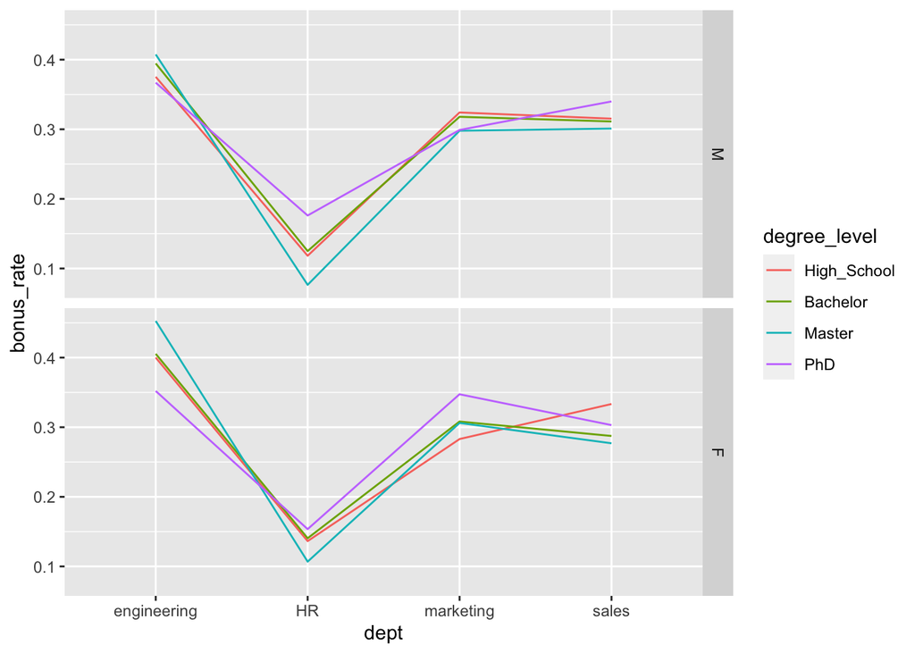

```r
employee_final %>%
  group_by(dept, degree_level, sex) %>%
  summarize(
    bonus_rate = sum(signing_bonus) / n()
  ) %>%
  ggplot(aes(dept, bonus_rate)) +
  geom_line(aes(color = degree_level, group = degree_level)) +
  facet_grid(vars(sex))
```

A quick plot shows that bonus rate seems irrelevant to sex and degree level but seems to be lower in the HR department. There is no obvious interaction pattern between these variables.

```r
bonus_lm <-
  glm(
    signing_bonus ~ degree_level + sex + dept,
    data = employee_final,
    family = 'binomial'
  )
```

```r
bonus_lm %>% summary()
```

```
##
## Call:
## glm(formula = signing_bonus ~ degree_level + sex + dept, family = "binomial",
##     data = employee_final)
##
## Deviance Residuals:
##     Min       1Q   Median       3Q      Max
## -1.0045  -0.8696  -0.8501   1.3691   2.0326
##
## Coefficients:
##                       Estimate Std. Error z value Pr(>|z|)
## (Intercept)          -0.438421   0.064123  -6.837 8.08e-12 ***
## degree_levelBachelor -0.001589   0.068911  -0.023    0.982
## degree_levelMaster   -0.038613   0.068821  -0.561    0.575
## degree_levelPhD       0.017177   0.068357   0.251    0.802
## sexF                 -0.002431   0.048297  -0.050    0.960
## deptHR               -1.450644   0.084214 -17.226  < 2e-16 ***
## deptmarketing        -0.354766   0.062449  -5.681 1.34e-08 ***
## deptsales            -0.354036   0.053597  -6.606 3.96e-11 ***
## ---
## Signif. codes:  0 '***' 0.001 '**' 0.01 '*' 0.05 '.' 0.1 ' ' 1
##
## (Dispersion parameter for binomial family taken to be 1)
##
##     Null deviance: 12239  on 9998  degrees of freedom
## Residual deviance: 11864  on 9991  degrees of freedom
## AIC: 11880
##
## Number of Fisher Scoring iterations: 4
```

Indeed, each department has significantly different bonus rates, with the HR department being the lowest and the engineering department being the highest.

#### Department

Does each department have the same criteria for hiring?

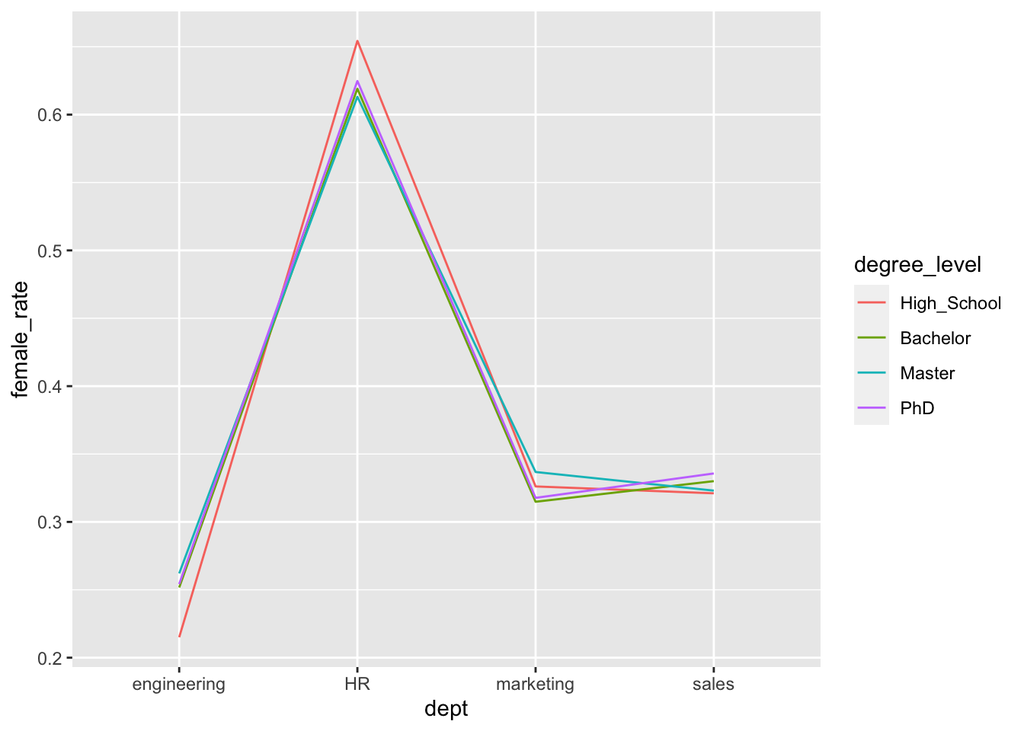

```r
employee_final %>%
  group_by(dept, degree_level) %>%
  summarize(
    female_rate = sum(sex == 'F') / n()
  ) %>%
  ggplot(aes(dept, female_rate)) +
  geom_line(aes(color = degree_level, group = degree_level))
```

The HR department clearly hires more females than males while the other 3 departments hire more males.

A chi-square test confirms that each department has significantly different gender distributions.

```r
employee_final %>%
  count(sex, dept) %>%
  pivot_wider(names_from = sex, values_from = n) %>%
  select(-dept) %>%
  chisq.test()
```

```
##
##  Pearson's Chi-squared test
##
## data:  .
## X-squared = 688.93, df = 3, p-value < 2.2e-16
```

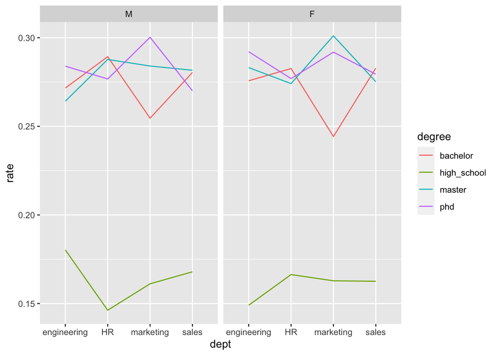

```r
employee_final %>%
  group_by(dept, sex) %>%
  summarize(
    high_school = sum(degree_level == 'High_School') / n(),
    bachelor = sum(degree_level == 'Bachelor') / n(),
    master = sum(degree_level == 'Master') / n(),
    phd = sum(degree_level == 'PhD') / n()
  ) %>%
  pivot_longer(cols = high_school:phd, names_to = "degree", values_to = "rate") %>%
  ggplot() +
  geom_line(aes(dept, rate, color = degree, group = degree)) +
  facet_grid(cols = vars(sex))
```

On the other hand, all departments seem to have very similar hiring standards for degree levels.

#### Company level

Does female have a fair representation on the managing levels?

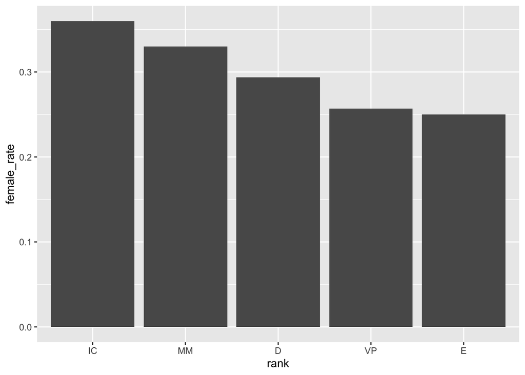

```r
employee_final %>%
  group_by(rank) %>%
  summarize(
    female_rate = sum(sex == "F") / n()
  ) %>%
  ggplot(aes(rank, female_rate)) +
  geom_col()
```

Firstly, the company has fewer females across all levels and female representation seems to get worse as the level increases.

```r
manager_lm <-
  glm(
    is_manager ~ degree_level + sex + dept + yrs_experience,
    data = employee_final %>% mutate(is_manager = (rank != "IC")),
    family = 'binomial'
  )
```

```r
manager_lm %>% summary()
```

```
##
## Call:
## glm(formula = is_manager ~ degree_level + sex + dept + yrs_experience,
##     family = "binomial", data = employee_final %>% mutate(is_manager = (rank !=
##         "IC")))
##
## Deviance Residuals:
##     Min       1Q   Median       3Q      Max
## -1.3871  -0.3134  -0.1973  -0.1248   3.2789
##
## Coefficients:
##                       Estimate Std. Error z value Pr(>|z|)
## (Intercept)          -6.202908   0.195528 -31.724  < 2e-16 ***
## degree_levelBachelor  0.592814   0.168647   3.515  0.00044 ***
## degree_levelMaster    0.987644   0.163942   6.024 1.70e-09 ***
## degree_levelPhD       1.029141   0.162856   6.319 2.63e-10 ***
## sexF                 -0.408918   0.096979  -4.217 2.48e-05 ***
## deptHR                0.111515   0.137917   0.809  0.41876
## deptmarketing         0.003487   0.130727   0.027  0.97872
## deptsales             0.049767   0.112082   0.444  0.65702
## yrs_experience        0.620473   0.017376  35.708  < 2e-16 ***
## ---
## Signif. codes:  0 '***' 0.001 '**' 0.01 '*' 0.05 '.' 0.1 ' ' 1
##
## (Dispersion parameter for binomial family taken to be 1)
##
##     Null deviance: 6497.1  on 9998  degrees of freedom
## Residual deviance: 3776.0  on 9990  degrees of freedom
## AIC: 3794
##
## Number of Fisher Scoring iterations: 6
```

Not surprisingly, you have roughly equal opportunities to become managers in all departments. Also, higher degrees and more years of experience increase the odds. Lastly and notably, females are less likely to become managers in this company!

#### Salary

```r
salary_lm <-
  lm(
    salary ~ degree_level + sex + dept + yrs_experience + rank + num_reports,
    data = employee_final
  )
```

```r
salary_lm %>% summary()
```

```
##
## Call:
## lm(formula = salary ~ degree_level + sex + dept + yrs_experience +
##     rank + num_reports, data = employee_final)
##
## Residuals:
##     Min      1Q  Median      3Q     Max
## -209583  -46463   -3156   45572  205822
##
## Coefficients:
##                        Estimate Std. Error t value Pr(>|t|)
## (Intercept)           239114.81    2365.77 101.073  < 2e-16 ***
## degree_levelBachelor    1702.67    2234.55   0.762  0.44609
## degree_levelMaster       806.01    2231.92   0.361  0.71801
## degree_levelPhD         2950.84    2229.69   1.323  0.18572
## sexF                     705.97    1554.07   0.454  0.64964
## deptHR               -159331.20    2298.90 -69.307  < 2e-16 ***
## deptmarketing         -49105.69    2117.19 -23.194  < 2e-16 ***
## deptsales             -49148.96    1831.06 -26.842  < 2e-16 ***
## yrs_experience           481.30     312.88   1.538  0.12401
## rankMM                  2036.89    3046.85   0.669  0.50381
## rankD                  16608.56    7148.06   2.324  0.02017 *
## rankVP                 50212.35   18072.13   2.778  0.00547 **
## rankE                 279411.96  113395.20   2.464  0.01375 *
## num_reports               37.54      42.96   0.874  0.38226
## ---
## Signif. codes:  0 '***' 0.001 '**' 0.01 '*' 0.05 '.' 0.1 ' ' 1
##
## Residual standard error: 71710 on 9985 degrees of freedom
## Multiple R-squared:  0.3492, Adjusted R-squared:  0.3483
## F-statistic: 412.1 on 13 and 9985 DF,  p-value: < 2.2e-16
```

The department and company level matters for salary, while degree level, sex, years of experience and number of reports do not have a significant impact on salary for a given department and company level.